# Biplot packages in R

Michael Friendly

2023-10-01

This document contains notes I initially prepared for a casual discussion session at the CARME23 meeting in Bonn, Sept. 24-28.

## Why talk?

There are quite a few implementations of biplots in R, but IMHO, **none** are sufficiently general to:

- become a current standard,
- with wide applicability, and
- easily used within modern R,
- encompassing the latest developments in the `tidyverse` and the `ggplot2` framework.

Does anyone want to join me in making biplots more accessible and easy to use in modern R?

### My problem

My problem, as a **user** and **explainer** is that with none of these can I

- easily create and describe simple examples of biplot methods
- with all the graphical attributes I want to control for a given example.

### What I’d like

- Provide a **common interface** for PCA / LDA and **all** related methods: E.g.,

> {`prcomp() / princomp() / MASS::lda(), …} -> a common “biplot” class object.
- Easily allow the different **scalings**, to show row/column variables in principal or standard coordinates.
- When there are groups, provide nice data ellipses or other bivariate summaries (convex hulls, …) for each group, with fine control over graphical attributes (color, fill, …), possibly direct labels for groups rather than a legend, etc.
- show row/observation points as points or observation labels.
- Be able to control the point/character size easily. Be able to filter out some point labels to highlight some more interesting ones.
- For variable vectors, control all graphical attributes: color, linewidth, font/sizes for variable names, etc.

## Discussion at CARME23

The following are some of the points raised by people at the *Biplot Software* session at CARME:

- Overplotting and labelling with auto / user defined shifting to avoid label overlap.
- Filtering what to plot and what to suppress
- Interactive plots and animation
- Simple default plot + possibilities to make it nice (decouple computations from representation)
- Ability to show density of samples
- Plot more than dim 1 & 2 - linked plots with same scales
- Specific to CA: is it standard or principal points for rows or cols, symmetric or asymmetric
- Needs to be a low level package to be used by other multivariate analysis packages

## Examples

These examples show biplots produced by some of these packages.

### Doing the PCA

The default method for `prcomp()` takes a numeric or complex matrix or data frame argument. By default, it does **not** scale the observations to unit variance, so `scale. = TRUE` should usually be specified. You can control the number of components returned using the `rank. argument.`

```r
data(iris)
iris.pca <- prcomp(iris[,1:4], scale. = TRUE)
```

There is also a formula method, which is more verbose, but more easily readable.

```r
iris.pca <- prcomp(~ Sepal.Length + Sepal.Width + Petal.Length + Petal.Width,
                   data=iris, scale. = TRUE)
```

You can also use tidy steps and pipes from **dplyr** to select variables, and perhaps filter out missing data.

```r
iris.pca <-
  iris |>
  dplyr::select(where(is.numeric)) |>
  prcomp(scale. = TRUE)
```

### ggbiplot

The default plot:

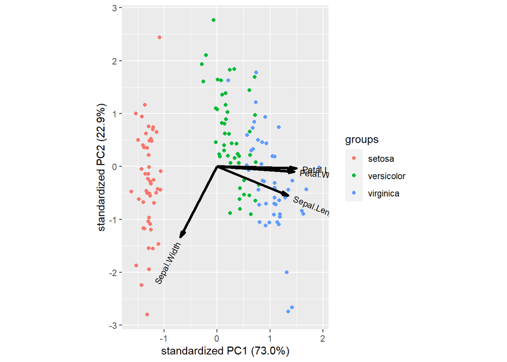

```r
library(ggbiplot)
library(ggplot2)
library(dplyr)
ggbiplot(iris.pca, groups = iris$Species)
```

Using more features:

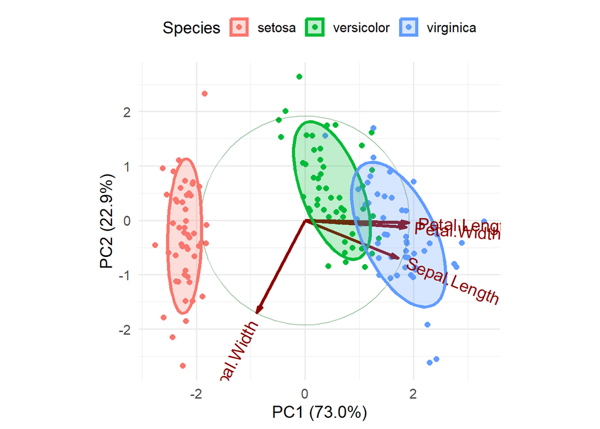

```r
iris.gg <-
  ggbiplot(iris.pca, obs.scale = 1, var.scale = 1,
           groups = iris$Species, point.size=2,
           varname.size = 5,
           varname.color = "darkred",
           varname.adjust = 1.2,
           ellipse = TRUE,
           circle = TRUE) +
  labs(fill = "Species", color = "Species") +
  theme_minimal(base_size = 14) +
  theme(legend.direction = 'horizontal', legend.position = 'top')
iris.gg
```

Use direct labels for the groups rather than a legend. This makes use of the fact that the `gg` object contains the dataset used `iris.gg$data` used to construct the plot.

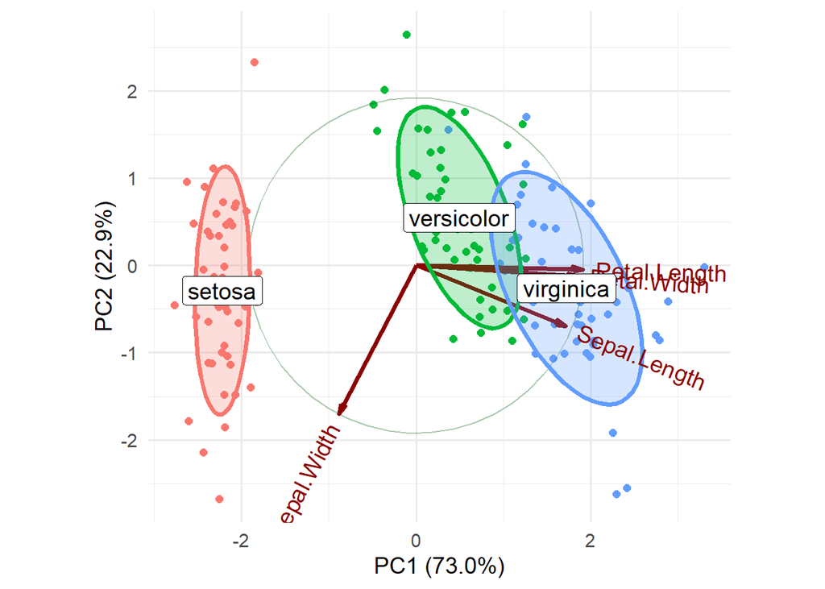

```r
# find means of the coordinates
group.labs <-
  iris.gg$data |>
  summarise(xvar = mean(xvar),
            yvar = mean(yvar), .by = groups)

iris.gg + geom_label(data = group.labs,
                     aes(x = xvar, y=yvar, label=groups),
                     size = 5) +
  theme(legend.position = "none")
```